# Optimal Treatment Analysis

## Outcome Variable

**Outcome Variable:** whz

## Predictor Variables

**Intervention Variable:** single

**Adjustment Set:**

- arm
- W_mage
- meducyrs
- feducyrs
- W_mhtcm
- W_mwtkg
- W_mbmi
- delta_W_mage
- delta_meducyrs
- delta_feducyrs
- delta_W_mhtcm
- delta_W_mwtkg
- delta_W_mbmi

## Stratifying Variables

The analysis was stratified on these variable(s):

- agecat
- studyid
- country

## Data Summary

| agecat | studyid | country | single | n_cell | n |
| --- | --- | --- | --- | --- | --- |
| Birth | COHORTS | GUATEMALA | 0 | 654 | 691 |
| Birth | COHORTS | GUATEMALA | 1 | 37 | 691 |
| Birth | COHORTS | INDIA | 0 | 4456 | 4463 |
| Birth | COHORTS | INDIA | 1 | 7 | 4463 |
| Birth | COHORTS | PHILIPPINES | 0 | 2789 | 2860 |
| Birth | COHORTS | PHILIPPINES | 1 | 71 | 2860 |
| Birth | JiVitA-4 | BANGLADESH | 0 | 2388 | 2393 |
| Birth | JiVitA-4 | BANGLADESH | 1 | 5 | 2393 |
| Birth | MAL-ED | BANGLADESH | 0 | 215 | 215 |
| Birth | MAL-ED | BANGLADESH | 1 | 0 | 215 |
| Birth | MAL-ED | BRAZIL | 0 | 54 | 62 |
| Birth | MAL-ED | BRAZIL | 1 | 8 | 62 |
| Birth | MAL-ED | INDIA | 0 | 45 | 45 |
| Birth | MAL-ED | INDIA | 1 | 0 | 45 |
| Birth | MAL-ED | NEPAL | 0 | 26 | 26 |
| Birth | MAL-ED | NEPAL | 1 | 0 | 26 |
| Birth | MAL-ED | PERU | 0 | 205 | 228 |
| Birth | MAL-ED | PERU | 1 | 23 | 228 |
| Birth | MAL-ED | SOUTH AFRICA | 0 | 63 | 120 |
| Birth | MAL-ED | SOUTH AFRICA | 1 | 57 | 120 |
| Birth | MAL-ED | TANZANIA, UNITED REPUBLIC OF | 0 | 112 | 115 |
| Birth | MAL-ED | TANZANIA, UNITED REPUBLIC OF | 1 | 3 | 115 |
| Birth | PROBIT | BELARUS | 0 | 13277 | 13817 |
| Birth | PROBIT | BELARUS | 1 | 540 | 13817 |
| Birth | ZVITAMBO | ZIMBABWE | 0 | 12065 | 12864 |
| Birth | ZVITAMBO | ZIMBABWE | 1 | 799 | 12864 |
| 6 months | COHORTS | GUATEMALA | 0 | 827 | 894 |
| 6 months | COHORTS | GUATEMALA | 1 | 67 | 894 |
| 6 months | COHORTS | INDIA | 0 | 4955 | 4964 |
| 6 months | COHORTS | INDIA | 1 | 9 | 4964 |

[output cut: 54 more lines]

The following strata were considered:

- agecat: 24 months, studyid: COHORTS, country: GUATEMALA
- agecat: 24 months, studyid: COHORTS, country: INDIA
- agecat: 24 months, studyid: COHORTS, country: PHILIPPINES
- agecat: 24 months, studyid: JiVitA-4, country: BANGLADESH
- agecat: 24 months, studyid: MAL-ED, country: BANGLADESH
- agecat: 24 months, studyid: MAL-ED, country: BRAZIL
- agecat: 24 months, studyid: MAL-ED, country: INDIA
- agecat: 24 months, studyid: MAL-ED, country: NEPAL
- agecat: 24 months, studyid: MAL-ED, country: PERU
- agecat: 24 months, studyid: MAL-ED, country: SOUTH AFRICA
- agecat: 24 months, studyid: MAL-ED, country: TANZANIA, UNITED REPUBLIC OF
- agecat: 24 months, studyid: PROBIT, country: BELARUS
- agecat: 24 months, studyid: TanzaniaChild2, country: TANZANIA, UNITED REPUBLIC OF
- agecat: 24 months, studyid: ZVITAMBO, country: ZIMBABWE
- agecat: 6 months, studyid: COHORTS, country: GUATEMALA
- agecat: 6 months, studyid: COHORTS, country: INDIA
- agecat: 6 months, studyid: COHORTS, country: PHILIPPINES
- agecat: 6 months, studyid: Guatemala BSC, country: GUATEMALA
- agecat: 6 months, studyid: JiVitA-4, country: BANGLADESH
- agecat: 6 months, studyid: MAL-ED, country: BANGLADESH
- agecat: 6 months, studyid: MAL-ED, country: BRAZIL
- agecat: 6 months, studyid: MAL-ED, country: INDIA
- agecat: 6 months, studyid: MAL-ED, country: NEPAL
- agecat: 6 months, studyid: MAL-ED, country: PERU
- agecat: 6 months, studyid: MAL-ED, country: SOUTH AFRICA
- agecat: 6 months, studyid: MAL-ED, country: TANZANIA, UNITED REPUBLIC OF
- agecat: 6 months, studyid: PROBIT, country: BELARUS
- agecat: 6 months, studyid: TanzaniaChild2, country: TANZANIA, UNITED REPUBLIC OF
- agecat: 6 months, studyid: ZVITAMBO, country: ZIMBABWE
- agecat: Birth, studyid: COHORTS, country: GUATEMALA
- agecat: Birth, studyid: COHORTS, country: INDIA
- agecat: Birth, studyid: COHORTS, country: PHILIPPINES
- agecat: Birth, studyid: JiVitA-4, country: BANGLADESH
- agecat: Birth, studyid: MAL-ED, country: BANGLADESH
- agecat: Birth, studyid: MAL-ED, country: BRAZIL
- agecat: Birth, studyid: MAL-ED, country: INDIA
- agecat: Birth, studyid: MAL-ED, country: NEPAL
- agecat: Birth, studyid: MAL-ED, country: PERU
- agecat: Birth, studyid: MAL-ED, country: SOUTH AFRICA
- agecat: Birth, studyid: MAL-ED, country: TANZANIA, UNITED REPUBLIC OF
- agecat: Birth, studyid: PROBIT, country: BELARUS
- agecat: Birth, studyid: ZVITAMBO, country: ZIMBABWE

### Dropped Strata

Some strata were dropped due to rare outcomes:

- agecat: Birth, studyid: MAL-ED, country: BANGLADESH
- agecat: Birth, studyid: MAL-ED, country: INDIA
- agecat: Birth, studyid: MAL-ED, country: NEPAL
- agecat: Birth, studyid: MAL-ED, country: TANZANIA, UNITED REPUBLIC OF
- agecat: 6 months, studyid: MAL-ED, country: BANGLADESH
- agecat: 6 months, studyid: MAL-ED, country: INDIA
- agecat: 6 months, studyid: MAL-ED, country: NEPAL
- agecat: 24 months, studyid: MAL-ED, country: BANGLADESH
- agecat: 24 months, studyid: MAL-ED, country: INDIA
- agecat: 24 months, studyid: MAL-ED, country: NEPAL
- agecat: 24 months, studyid: TanzaniaChild2, country: TANZANIA, UNITED REPUBLIC OF

## Methods Detail

We’re interested in the causal parameters $E[Y_a]$ for all values of $a \in \mathcal{A}$. These parameters represent the mean outcome if, possibly contrary to fact, we intervened to set all units to have $A=a$. Under the randomization and positivity assumptions, these are identified by the statistical parameters $\psi_a=E_W[E_{Y|A,W}(Y|A=a,W)]$. In addition, we’re interested in the mean of $Y$, $E[Y]$ under no intervention (the observed mean). We will estimate these parameters by using SuperLearner to fit the relevant likelihood factors – $E_{Y|A,W}(Y|A=a,W)$ and $p(A=a|W)$, and then updating our likelihood fit using a joint TMLE.

For unadjusted analyses ($W=\{\}$), initial likelihoods were estimated using Lrnr_glm to estimate the simple $E(Y|A)$ and Lrnr_mean to estimate $p(A)$. For adjusted analyses, a small library containing Lrnr_glmnet, Lrnr_xgboost, and Lrnr_mean was used.

Having estimated these parameters, we will then use the delta method to estimate relative risks and attributable risks relative to a prespecified baseline level of $A$.

# Results Detail

## Results Plots

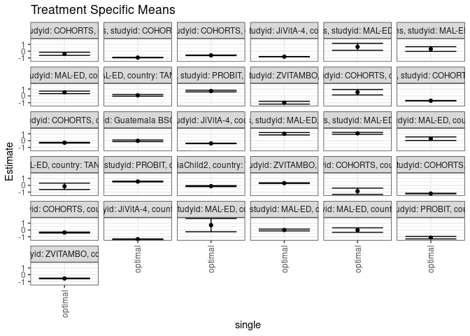

## Results Table

### Parameter: TSM

| agecat | studyid | country | intervention_level | baseline_level | estimate | ci_lower | ci_upper |
| --- | --- | --- | --- | --- | --- | --- | --- |
| Birth | COHORTS | GUATEMALA | optimal | observed | -0.8735631 | -1.3338489 | -0.4132773 |
| Birth | COHORTS | INDIA | optimal | observed | -1.2176978 | -1.2623529 | -1.1730427 |
| Birth | COHORTS | PHILIPPINES | optimal | observed | -0.3758064 | -0.4441070 | -0.3075059 |
| Birth | JiVitA-4 | BANGLADESH | optimal | observed | -1.3524839 | -1.3940592 | -1.3109086 |
| Birth | MAL-ED | BRAZIL | optimal | observed | 0.7093774 | -0.2579964 | 1.6767513 |
| Birth | MAL-ED | PERU | optimal | observed | -0.0032966 | -0.1402867 | 0.1336935 |
| Birth | MAL-ED | SOUTH AFRICA | optimal | observed | -0.0140239 | -0.3431390 | 0.3150912 |
| Birth | PROBIT | BELARUS | optimal | observed | -1.1218814 | -1.3112757 | -0.9324870 |
| Birth | ZVITAMBO | ZIMBABWE | optimal | observed | -0.5547653 | -0.6030249 | -0.5065057 |
| 6 months | COHORTS | GUATEMALA | optimal | observed | 0.5325349 | 0.1363007 | 0.9287692 |
| 6 months | COHORTS | INDIA | optimal | observed | -0.7098951 | -0.7430288 | -0.6767613 |
| 6 months | COHORTS | PHILIPPINES | optimal | observed | -0.3136906 | -0.3632077 | -0.2641734 |
| 6 months | Guatemala BSC | GUATEMALA | optimal | observed | -0.0333381 | -0.1547097 | 0.0880336 |
| 6 months | JiVitA-4 | BANGLADESH | optimal | observed | -0.4157186 | -0.4534584 | -0.3779789 |
| 6 months | MAL-ED | BRAZIL | optimal | observed | 1.0019002 | 0.8261765 | 1.1776240 |
| 6 months | MAL-ED | PERU | optimal | observed | 1.0600133 | 0.9163756 | 1.2036510 |
| 6 months | MAL-ED | SOUTH AFRICA | optimal | observed | 0.2769398 | 0.0175300 | 0.5363496 |
| 6 months | MAL-ED | TANZANIA, UNITED REPUBLIC OF | optimal | observed | -0.1532421 | -0.6210085 | 0.3145242 |
| 6 months | PROBIT | BELARUS | optimal | observed | 0.5517936 | 0.4948171 | 0.6087700 |
| 6 months | TanzaniaChild2 | TANZANIA, UNITED REPUBLIC OF | optimal | observed | -0.1263932 | -0.2007336 | -0.0520529 |
| 6 months | ZVITAMBO | ZIMBABWE | optimal | observed | 0.3132411 | 0.2607601 | 0.3657221 |
| 24 months | COHORTS | GUATEMALA | optimal | observed | -0.3839156 | -0.6136964 | -0.1541348 |
| 24 months | COHORTS | INDIA | optimal | observed | -0.9379445 | -0.9726916 | -0.9031975 |
| 24 months | COHORTS | PHILIPPINES | optimal | observed | -0.6103989 | -0.6551912 | -0.5656067 |
| 24 months | JiVitA-4 | BANGLADESH | optimal | observed | -0.8055798 | -0.8211824 | -0.7899772 |
| 24 months | MAL-ED | BRAZIL | optimal | observed | 0.6377376 | 0.1267158 | 1.1487593 |
| 24 months | MAL-ED | PERU | optimal | observed | 0.3133268 | -0.0343523 | 0.6610059 |
| 24 months | MAL-ED | SOUTH AFRICA | optimal | observed | 0.5196630 | 0.3316145 | 0.7077114 |
| 24 months | MAL-ED | TANZANIA, UNITED REPUBLIC OF | optimal | observed | 0.0761158 | -0.0487554 | 0.2009869 |
| 24 months | PROBIT | BELARUS | optimal | observed | 0.7039101 | 0.5837211 | 0.8240991 |
| 24 months | ZVITAMBO | ZIMBABWE | optimal | observed | -1.0015745 | -1.2128904 | -0.7902587 |

### Parameter: E(Y)

| agecat | studyid | country | intervention_level | baseline_level | estimate | ci_lower | ci_upper |
| --- | --- | --- | --- | --- | --- | --- | --- |
| Birth | COHORTS | GUATEMALA | observed | observed | -1.0552243 | -1.1617873 | -0.9486614 |
| Birth | COHORTS | INDIA | observed | observed | -0.9765068 | -1.0113301 | -0.9416835 |
| Birth | COHORTS | PHILIPPINES | observed | observed | -0.7377902 | -0.7844819 | -0.6910986 |
| Birth | JiVitA-4 | BANGLADESH | observed | observed | -0.6888174 | -0.7412201 | -0.6364147 |
| Birth | MAL-ED | BRAZIL | observed | observed | 0.4029032 | 0.0896793 | 0.7161272 |
| Birth | MAL-ED | PERU | observed | observed | -0.0520175 | -0.1725298 | 0.0684947 |
| Birth | MAL-ED | SOUTH AFRICA | observed | observed | -0.1925833 | -0.4053570 | 0.0201904 |
| Birth | PROBIT | BELARUS | observed | observed | -1.1491782 | -1.3593933 | -0.9389630 |
| Birth | ZVITAMBO | ZIMBABWE | observed | observed | -0.5148609 | -0.5407634 | -0.4889583 |
| 6 months | COHORTS | GUATEMALA | observed | observed | 0.1920134 | 0.1173734 | 0.2666534 |
| 6 months | COHORTS | INDIA | observed | observed | -0.7104795 | -0.7428008 | -0.6781581 |
| 6 months | COHORTS | PHILIPPINES | observed | observed | -0.2936948 | -0.3352840 | -0.2521057 |
| 6 months | Guatemala BSC | GUATEMALA | observed | observed | -0.0568833 | -0.1722874 | 0.0585208 |
| 6 months | JiVitA-4 | BANGLADESH | observed | observed | -0.3904664 | -0.4277855 | -0.3531473 |
| 6 months | MAL-ED | BRAZIL | observed | observed | 0.9720774 | 0.8078144 | 1.1363403 |
| 6 months | MAL-ED | PERU | observed | observed | 1.0528816 | 0.9313005 | 1.1744626 |
| 6 months | MAL-ED | SOUTH AFRICA | observed | observed | 0.5421785 | 0.3900443 | 0.6943126 |
| 6 months | MAL-ED | TANZANIA, UNITED REPUBLIC OF | observed | observed | 0.5362213 | 0.4049390 | 0.6675036 |
| 6 months | PROBIT | BELARUS | observed | observed | 0.5741099 | 0.5141290 | 0.6340908 |
| 6 months | TanzaniaChild2 | TANZANIA, UNITED REPUBLIC OF | observed | observed | 0.0797577 | 0.0268998 | 0.1326156 |
| 6 months | ZVITAMBO | ZIMBABWE | observed | observed | 0.3108992 | 0.2851818 | 0.3366167 |
| 24 months | COHORTS | GUATEMALA | observed | observed | -0.2796964 | -0.3351582 | -0.2242346 |
| 24 months | COHORTS | INDIA | observed | observed | -0.6594122 | -0.6925753 | -0.6262491 |
| 24 months | COHORTS | PHILIPPINES | observed | observed | -0.6100579 | -0.6471813 | -0.5729344 |
| 24 months | JiVitA-4 | BANGLADESH | observed | observed | -1.2239898 | -1.2559235 | -1.1920562 |
| 24 months | MAL-ED | BRAZIL | observed | observed | 0.4626233 | 0.2567495 | 0.6684971 |
| 24 months | MAL-ED | PERU | observed | observed | 0.1111982 | -0.0118399 | 0.2342362 |
| 24 months | MAL-ED | SOUTH AFRICA | observed | observed | 0.4090301 | 0.2879441 | 0.5301161 |
| 24 months | MAL-ED | TANZANIA, UNITED REPUBLIC OF | observed | observed | 0.0547975 | -0.0703378 | 0.1799328 |
| 24 months | PROBIT | BELARUS | observed | observed | 0.6981406 | 0.5843775 | 0.8119038 |
| 24 months | ZVITAMBO | ZIMBABWE | observed | observed | -1.1797222 | -1.2787189 | -1.0807256 |

### Parameter: PAR

| agecat | studyid | country | intervention_level | baseline_level | estimate | ci_lower | ci_upper |
| --- | --- | --- | --- | --- | --- | --- | --- |
| Birth | COHORTS | GUATEMALA | optimal | observed | -0.1816612 | -0.6314089 | 0.2680866 |
| Birth | COHORTS | INDIA | optimal | observed | 0.2411910 | 0.2026735 | 0.2797085 |
| Birth | COHORTS | PHILIPPINES | optimal | observed | -0.3619838 | -0.4259366 | -0.2980309 |
| Birth | JiVitA-4 | BANGLADESH | optimal | observed | 0.6636665 | 0.6057635 | 0.7215695 |
| Birth | MAL-ED | BRAZIL | optimal | observed | -0.3064742 | -1.2192159 | 0.6062674 |
| Birth | MAL-ED | PERU | optimal | observed | -0.0487209 | -0.1640377 | 0.0665958 |
| Birth | MAL-ED | SOUTH AFRICA | optimal | observed | -0.1785594 | -0.3974696 | 0.0403507 |
| Birth | PROBIT | BELARUS | optimal | observed | -0.0272968 | -0.1227867 | 0.0681931 |
| Birth | ZVITAMBO | ZIMBABWE | optimal | observed | 0.0399045 | -0.0008567 | 0.0806657 |
| 6 months | COHORTS | GUATEMALA | optimal | observed | -0.3405215 | -0.7291619 | 0.0481189 |
| 6 months | COHORTS | INDIA | optimal | observed | -0.0005844 | -0.0018993 | 0.0007306 |
| 6 months | COHORTS | PHILIPPINES | optimal | observed | 0.0199958 | -0.0110102 | 0.0510017 |
| 6 months | Guatemala BSC | GUATEMALA | optimal | observed | -0.0235452 | -0.0652594 | 0.0181690 |
| 6 months | JiVitA-4 | BANGLADESH | optimal | observed | 0.0252522 | 0.0118176 | 0.0386868 |
| 6 months | MAL-ED | BRAZIL | optimal | observed | -0.0298229 | -0.1024611 | 0.0428154 |
| 6 months | MAL-ED | PERU | optimal | observed | -0.0071317 | -0.1100900 | 0.0958265 |
| 6 months | MAL-ED | SOUTH AFRICA | optimal | observed | 0.2652387 | 0.0503697 | 0.4801077 |
| 6 months | MAL-ED | TANZANIA, UNITED REPUBLIC OF | optimal | observed | 0.6894635 | 0.2296951 | 1.1492318 |
| 6 months | PROBIT | BELARUS | optimal | observed | 0.0223164 | 0.0082755 | 0.0363572 |
| 6 months | TanzaniaChild2 | TANZANIA, UNITED REPUBLIC OF | optimal | observed | 0.2061509 | 0.1499516 | 0.2623503 |
| 6 months | ZVITAMBO | ZIMBABWE | optimal | observed | -0.0023419 | -0.0472872 | 0.0426034 |
| 24 months | COHORTS | GUATEMALA | optimal | observed | 0.1042193 | -0.1142137 | 0.3226522 |
| 24 months | COHORTS | INDIA | optimal | observed | 0.2785323 | 0.2362758 | 0.3207888 |
| 24 months | COHORTS | PHILIPPINES | optimal | observed | 0.0003411 | -0.0234009 | 0.0240830 |
| 24 months | JiVitA-4 | BANGLADESH | optimal | observed | -0.4184101 | -0.4543883 | -0.3824318 |
| 24 months | MAL-ED | BRAZIL | optimal | observed | -0.1751143 | -0.6633657 | 0.3131371 |
| 24 months | MAL-ED | PERU | optimal | observed | -0.2021286 | -0.5292794 | 0.1250222 |
| 24 months | MAL-ED | SOUTH AFRICA | optimal | observed | -0.1106329 | -0.2754367 | 0.0541710 |
| 24 months | MAL-ED | TANZANIA, UNITED REPUBLIC OF | optimal | observed | -0.0213182 | -0.0522292 | 0.0095927 |
| 24 months | PROBIT | BELARUS | optimal | observed | -0.0057695 | -0.0223216 | 0.0107826 |
| 24 months | ZVITAMBO | ZIMBABWE | optimal | observed | -0.1781477 | -0.3920579 | 0.0357625 |